# Tutorial: Introduction to palaeoverse

Palaeoverse Team

2022-10-18

`palaeoverse` is an *R* package developed by palaeobiologists, for palaeobiologists.

This tutorial will guide you through the installation and some key functions with the `palaeoverse` package.

# Installation

The development version of `palaeoverse` can be installed via GitHub. First, install the `devtools` package, and then use the `install_github` function within this package to install `palaeoverse` directly from GitHub.

```r
install.packages("devtools")
```

```r
devtools::install_github("palaeoverse-community/palaeoverse")
```

Now attach `palaeoverse` with the regular library function:

```r
library(palaeoverse)
```

If you use `palaeoverse` in your manuscripts, you can cite it by using the following function:

```r
citation("palaeoverse")
```

# Using the package

The aim of `palaeoverse` is to generate a community-driven software package of generic functions for the palaeobiological community. The package does not provide implementations of statistical analyses, rather it provides auxiliary functions to help streamline analyses and improve code readability and reproducibility.

```r
# call up the dataset by name:
data(tetrapods)

# view the first five lines:
head(tetrapods)
```

[output not shown]

# Exploring the data

Before conducting any analyses, it is important to explore your data. For more information on the variables in the `tetrapods` dataset, you can take a look at the documentation, by typing `?tetrapods` into the R console.

Let’s start by exploring the data a little:

```r
# how many occurrences (each row is an individual occurrence):
length(tetrapods$occurrence_no)
```

```
## [1] 5270
```

```r
# how many individual taxa:
length(unique(tetrapods$accepted_name))
```

```
## [1] 1801
```

```r
# how many individual 'collections' (=localities):
length(unique(tetrapods$collection_no))
```

```
## [1] 1739
```

# Exploring the functions

### 1. Filter occurrences to unique taxa

In many cases palaeobiologists count unique taxa by retaining only unique occurrences identified to a given taxonomic resolution (e.g. genera or species), however this can result in some useful information being discarded. The `tax_unique` function retains occurrences identified to a coarser taxonomic resolution which are not already represented within the dataset. Take, for example, the following occurrences:

- *Albertosaurus sarcophagus*
- *Ankylosaurus* sp.
- *Ceratopsidae* indet.
- *Ornithominu*s sp.
- *Tyrannosaurus rex*

This function can be especially useful for when looking at alpha diversity (local richness). Let’s apply it to the `tetrapods` dataset, by filtering it to genus-level.

```r
# filter to species-level:
tet_genera <- tax_unique(occdf = tetrapods, genus = "genus", family = "family",
                      order = "order", class = "class", resolution = "genus")
```

```r
tet_genera[1008, ]
```

```
##             class         order       family genus         unique_name
## 1008 Osteichthyes Temnospondyli Melosauridae  <NA> Melosauridae indet.
```

Now, let’s use this function to record the number of unique occurrences by collection (=locality) with group_apply:

```r
coll_genera <- group_apply(occdf = tetrapods,
                     group = c("collection_no"),
                     fun = tax_unique,
                     genus = "genus",
                     family = "family",
                     order = "order",
                     class = "class",
                     resolution = "genus")

# see structure of the new dataframe:
str(coll_genera)
```

```
## 'data.frame':    4391 obs. of  6 variables:
##  $ class        : chr  "Osteichthyes" "Osteichthyes" "Osteichthyes" "Reptilia" ...
##  $ order        : chr  NA "Temnospondyli" "Cotylosauria" NA ...
##  $ family       : chr  NA "Dissorophidae" NA "Bolosauridae" ...
##  $ genus        : chr  NA "Parioxys" "Archeria" "Bolosaurus" ...
##  $ unique_name  : chr  "Osteichthyes indet." "Parioxys sp." "Archeria sp." "Bolosaurus sp." ...
##  $ collection_no: chr  "11149" "11152" "11165" "11165" ...
```

Next, let’s count the number of unique taxa per collection (=locality)

```r
coll_taxa <- aggregate(coll_genera$unique_name, by=list(coll_genera$collection_no), FUN=length)

# rename column names:
colnames(coll_taxa) <- c("collection_no","n_taxa")

# take a look at the new dataframe
head(coll_taxa)
```

```
##   collection_no n_taxa
## 1        101069      1
## 2        101956      1
## 3        104796      1
## 4        105043      2
## 5        105082      1
## 6        105083      4
```

To plot an alpha diversity (local richness) plot, we will need the ages of intervals in millions of years. Let’s grab these from the main `tetrapods` dataset.

```r
# take the columns pertaining to collections and their ages in millions of years:
coll_info <- data.frame(tetrapods$collection_no, tetrapods$max_ma, tetrapods$max_ma)

# rename column names:
colnames(coll_info) <- c("collection_no","max_ma", "min_ma")

# create a new column for the midpoint of each collection:
coll_info$mid_ma <- (coll_info$max_ma + coll_info$min_ma) / 2

# remove duplicated collections based on the collection number (column 1)
coll_info <- coll_info[!duplicated(coll_info[1]),]

# combine this dataframe with the dataframe from above
alpha_data <- merge(coll_info, coll_taxa, by = "collection_no")

# take a look:
head(alpha_data)
```

```
##   collection_no max_ma min_ma mid_ma n_taxa
## 1         11149  290.1  290.1  290.1      1
## 2         11152  295.5  295.5  295.5      1
## 3         11165  298.9  298.9  298.9      9
## 4         11323  303.4  303.4  303.4      1
## 5         12943  305.9  305.9  305.9      1
## 6         12976  279.3  279.3  279.3      7
```

Time to plot alpha diversity! Let’s start with a simple scatterplot:

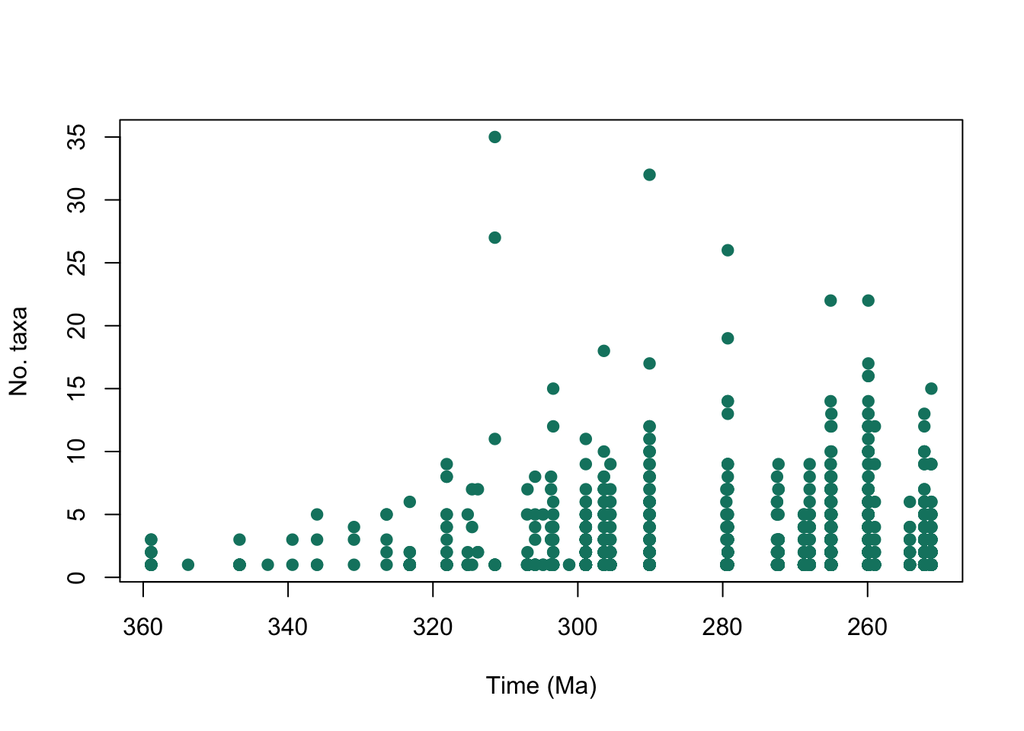

```r
plot(alpha_data$mid_ma, alpha_data$n_taxa, # add the points
     xlim = rev(range(alpha_data$mid_ma)), # reverse the x-axis
     xlab="Time (Ma)", ylab="No. taxa", # axes labels
     pch = 19, col = "#0e826f") # point style and colour
```

### 2. Adding a geological timescale to a plot axis

Sometimes, we might like to add a geological timescale to our plots. `axis_geo()` adds a geological timescale between the plot and the axis.

Taking our plot from above, let’s use this function to add a timescale to the x-axis

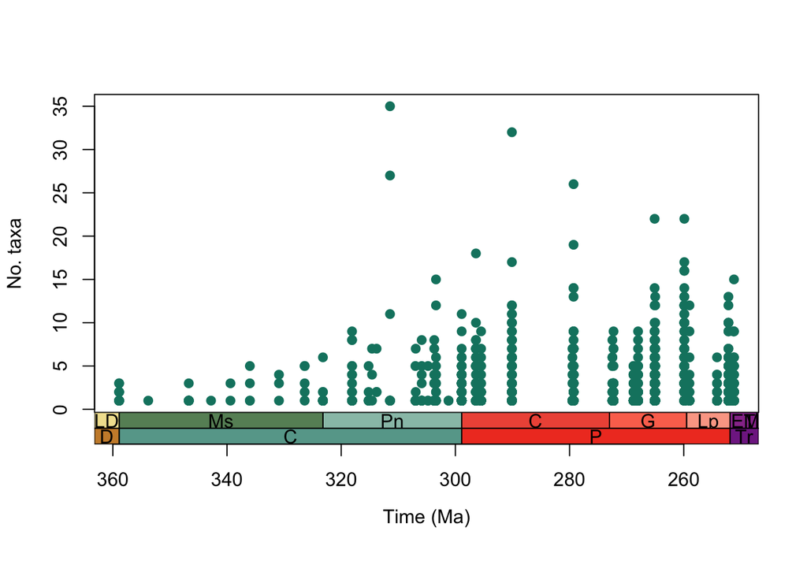

```r
# set margins
par(mar = c(7.1, 4.1, 4.1, 2.1)) # expand at bottom if adding more interval categories

# alpha diversity plot
plot(alpha_data$mid_ma, alpha_data$n_taxa, # add the points
     axes = FALSE,
     xlim = rev(range(alpha_data$mid_ma)), # reverse the x-axis
     xlab=" ", ylab="No. taxa", # axes labels
     pch = 19, col = "#0e826f") # point style and colour
box()
axis(2)
axis_geo(side = 1, intervals = list("epochs", "periods"))
title(xlab = "Time (Ma)", line = 4)
```